# Guía de parentesco y endogamia

Genética y Genómica en Producción Animal

Dr. José A. Gallardo.

Profesor adjunto de la Pontificia Universidad Católica de Valparaíso  
jose.gallardo@pucv.cl

April 08, 2021

#### OBJETIVO DE APRENDIZAJE

Importar, elaborar y manipular genealogías de animales calculando parámetros genéticos como el coeficiente de parentesco, de coascendencia y el nivel de endogamia individual.

#### INSTRUCCIONES GENERALES

1.- Resuelva los ejercicios propuestos en el siguiente proyecto colaborativo de Rstudio cloud [Pedigree](https://rstudio.cloud/spaces/132848/project/2391478)

2.- Compile el código con el botón Knit y guardelo en formato html.

3.- Comparta su reporte en la carpeta Drive de la [clase 2](https://drive.google.com/drive/folders/1D1XNAMuPR5HGyQ9Os4xk2VUak2dj4V-x?usp=sharing)

#### MARCO TEORICO Y LIBRERIAS

Los estudios de parentesco y endogamia son una parte central de los análsis genéticos en producción animal y acuicultura. Estos estudios son muy útiles para seleccionar adecuadamente a los reproductores [(Gallardo et al. 2004a)](https://aquagenetics.files.wordpress.com/2011/11/2004a-gallardo-et-al1.pdf) tratando d eminimizar el parentesco o para evaluar los efectos perjudiciales de la endogamia [(Gallardo et al. 2004b)](https://aquagenetics.files.wordpress.com/2011/11/2004b-gallardo-et-al.pdf) en animales.

La librería **[kinship2](https://www.karger.com/Article/Pdf/363105)** (Sinwell et al. 2014) crea y manipula datos de pedigree, calcula diferentes parámetros genéticos incluyendo una medida simple del coeficiente de parentesco denominada **kinship**.

El coeficiente **kinship** mide la probabilidad de que un alelo tomado al azar de un individuo i, y otro alelo tomado al azar de un individuo j sean identicos por descendencia.

El **coeficiente de parentesco aditivo** (Wright, 1922) se puede calcular facilmente como 2 veces el coeficiente de kinship. Esta librería permite además generar gráficas de genealogías completas o parciales de manera muy robusta.

La librería **pedigree** (Albart Coster, 2012) analiza y transforma datos de pedigree. Incluye funciones para añadir individuos sin registro y para calcular el **coeficiente de endogamia individual**, entre otras.

#### EJERCICIOS

**Ejercicio 1**

Cree un documento Rmarkdown (File -> New File -> R Markdown) denominado y guardelo en su directorio como **Guia_Pedigree_Animal**.

**Ejercicio 2**

En el primier bloque de códigos o chunk configure los comandos de la siguiente manera *knitr::opts_chunk$set(echo = TRUE)* y cargue las librerías **kinship2**, **pedigree**, **knitr**, **pander** y **readxl** usando el comando **library()**. Si alguna librería no está habilitada instálela previamente con este comando **install.packages("")**.

**Ejercicio 3** Genealogía de población de peces con albinismo.

Cree un objeto denominado *Fish* con el set de datos *“PED.xlsx”* usando los comandos *<-* y *read_excel(“file.xlsx”)*. Incluya los argumentos *sheet*, *col_names*, y *na* para leer la primera hoja de cálculo, los encabezados de las columnas y los valores perdidos.

Imprima la tabla de datos con el comando *knitr::kable()* e incluya una leyenda d ela tabla.

Genealogía en formato kinship2.

| id | fatherid | motherid | sex | affected |
| --- | --- | --- | --- | --- |
| 1 | NA | NA | 1 | 1 |
| 2 | NA | NA | 2 | 0 |
| 3 | NA | NA | 1 | 0 |
| 4 | NA | NA | 2 | 0 |
| 5 | 1 | 2 | 1 | 0 |
| 6 | 1 | 2 | 1 | 0 |
| 7 | 3 | 4 | 2 | 0 |
| 8 | 6 | 7 | 1 | 0 |
| 9 | 6 | 7 | 1 | 0 |
| 10 | 6 | 7 | 2 | 1 |

**Ejercicio 4**

Cree un objeto pedigree denominado *Fish_ped* a partir del set de datos Fish. Use el comando pedigree de la librería kinship2.

```r
Fish_ped <- with(Fish,pedigree(id=id,dadid=fatherid,momid=motherid, sex=sex, affected = affected))
```

**Ejercicio 5**

Grafique la genealogía con el comando plot(). Incluya una leyenda de la figura con el comando fig.cap="" de Rmarkdown.

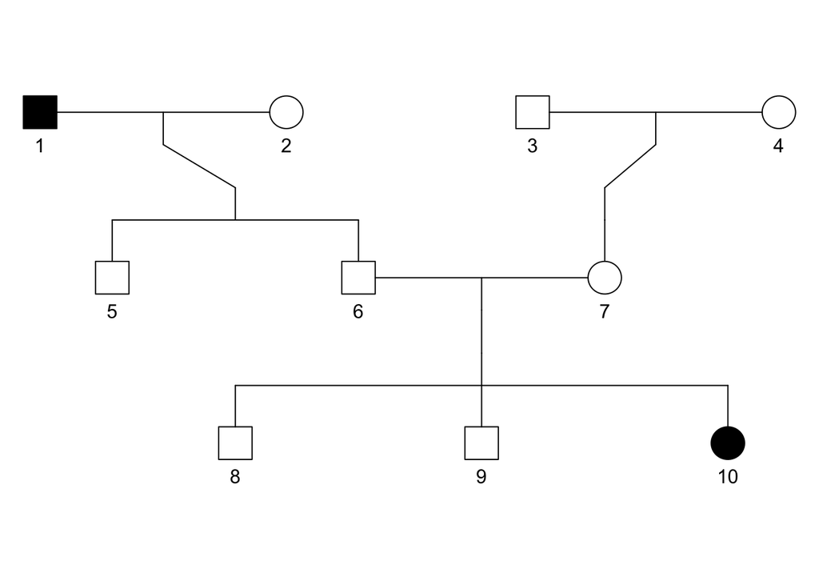

Genealogía de población con albinismo. Los individuos en negrita tienen albinismo

**Ejercicio 6**

Cree un objeto denominado *kin* y almacene ahí el coeficiente de parentesco que entrega la función kinship(). No olvide multiplicar por 2.

```r
kin <- kinship(Fish_ped)
kin <- kin*2

knitr::kable(
  kin,  row.names = TRUE,
  caption = "Matriz de coeficientes de kinship")
```

Matriz de coeficientes de kinship

|  | 1 | 2 | 3 | 4 | 5 | 6 | 7 | 8 | 9 | 10 |
| --- | --- | --- | --- | --- | --- | --- | --- | --- | --- | --- |
| 1 | 1.00 | 0.00 | 0.00 | 0.00 | 0.50 | 0.5 | 0.0 | 0.25 | 0.25 | 0.25 |
| 2 | 0.00 | 1.00 | 0.00 | 0.00 | 0.50 | 0.5 | 0.0 | 0.25 | 0.25 | 0.25 |
| 3 | 0.00 | 0.00 | 1.00 | 0.00 | 0.00 | 0.0 | 0.5 | 0.25 | 0.25 | 0.25 |
| 4 | 0.00 | 0.00 | 0.00 | 1.00 | 0.00 | 0.0 | 0.5 | 0.25 | 0.25 | 0.25 |
| 5 | 0.50 | 0.50 | 0.00 | 0.00 | 1.00 | 0.5 | 0.0 | 0.25 | 0.25 | 0.25 |
| 6 | 0.50 | 0.50 | 0.00 | 0.00 | 0.50 | 1.0 | 0.0 | 0.50 | 0.50 | 0.50 |
| 7 | 0.00 | 0.00 | 0.50 | 0.50 | 0.00 | 0.0 | 1.0 | 0.50 | 0.50 | 0.50 |
| 8 | 0.25 | 0.25 | 0.25 | 0.25 | 0.25 | 0.5 | 0.5 | 1.00 | 0.50 | 0.50 |
| 9 | 0.25 | 0.25 | 0.25 | 0.25 | 0.25 | 0.5 | 0.5 | 0.50 | 1.00 | 0.50 |
| 10 | 0.25 | 0.25 | 0.25 | 0.25 | 0.25 | 0.5 | 0.5 | 0.50 | 0.50 | 1.00 |

**Ejercicio 7**

Investigue la función lower.tri() y ejecute los siguientes comandos uno a uno: a) lower.tri(kin) b) kin[lower.tri(kin, diag = TRUE)] <- NA c) kin

¿Qué ha sucedido con los valores de la diagonal y con los valores de la triangular inferior?

```r
lower.tri(kin)
```

```
##        [,1]  [,2]  [,3]  [,4]  [,5]  [,6]  [,7]  [,8]  [,9] [,10]
##  [1,] FALSE FALSE FALSE FALSE FALSE FALSE FALSE FALSE FALSE FALSE
##  [2,]  TRUE FALSE FALSE FALSE FALSE FALSE FALSE FALSE FALSE FALSE
##  [3,]  TRUE  TRUE FALSE FALSE FALSE FALSE FALSE FALSE FALSE FALSE
##  [4,]  TRUE  TRUE  TRUE FALSE FALSE FALSE FALSE FALSE FALSE FALSE
##  [5,]  TRUE  TRUE  TRUE  TRUE FALSE FALSE FALSE FALSE FALSE FALSE
##  [6,]  TRUE  TRUE  TRUE  TRUE  TRUE FALSE FALSE FALSE FALSE FALSE
##  [7,]  TRUE  TRUE  TRUE  TRUE  TRUE  TRUE FALSE FALSE FALSE FALSE
##  [8,]  TRUE  TRUE  TRUE  TRUE  TRUE  TRUE  TRUE FALSE FALSE FALSE
##  [9,]  TRUE  TRUE  TRUE  TRUE  TRUE  TRUE  TRUE  TRUE FALSE FALSE
## [10,]  TRUE  TRUE  TRUE  TRUE  TRUE  TRUE  TRUE  TRUE  TRUE FALSE
```

```r
kin[lower.tri(kin, diag = TRUE)] <- NA

kin
```

```
##     1  2  3  4   5   6   7    8    9   10
## 1  NA  0  0  0 0.5 0.5 0.0 0.25 0.25 0.25
## 2  NA NA  0  0 0.5 0.5 0.0 0.25 0.25 0.25
## 3  NA NA NA  0 0.0 0.0 0.5 0.25 0.25 0.25
## 4  NA NA NA NA 0.0 0.0 0.5 0.25 0.25 0.25
## 5  NA NA NA NA  NA 0.5 0.0 0.25 0.25 0.25
## 6  NA NA NA NA  NA  NA 0.0 0.50 0.50 0.50
## 7  NA NA NA NA  NA  NA  NA 0.50 0.50 0.50
## 8  NA NA NA NA  NA  NA  NA   NA 0.50 0.50
## 9  NA NA NA NA  NA  NA  NA   NA   NA 0.50
## 10 NA NA NA NA  NA  NA  NA   NA   NA   NA
```

**Ejercicio 8**  
Cree un objeto denominado *coef_kin* y transforme la nueva matriz kin a vector con el comando as.vector(). Realice un histograma de los coeficientes de parentesco con la función hist() y calcule estadística descriptiva con el comando summary().

```r
coef_kin <- as.vector(kin)
coef_kin
```

```
##   [1]   NA   NA   NA   NA   NA   NA   NA   NA   NA   NA 0.00   NA   NA   NA   NA
##  [16]   NA   NA   NA   NA   NA 0.00 0.00   NA   NA   NA   NA   NA   NA   NA   NA
##  [31] 0.00 0.00 0.00   NA   NA   NA   NA   NA   NA   NA 0.50 0.50 0.00 0.00   NA
##  [46]   NA   NA   NA   NA   NA 0.50 0.50 0.00 0.00 0.50   NA   NA   NA   NA   NA
##  [61] 0.00 0.00 0.50 0.50 0.00 0.00   NA   NA   NA   NA 0.25 0.25 0.25 0.25 0.25
##  [76] 0.50 0.50   NA   NA   NA 0.25 0.25 0.25 0.25 0.25 0.50 0.50 0.50   NA   NA
##  [91] 0.25 0.25 0.25 0.25 0.25 0.50 0.50 0.50 0.50   NA
```

```r
summary(coef_kin)
```

```
##    Min. 1st Qu.  Median    Mean 3rd Qu.    Max.    NA's
##  0.0000  0.0000  0.2500  0.2611  0.5000  0.5000      55
```

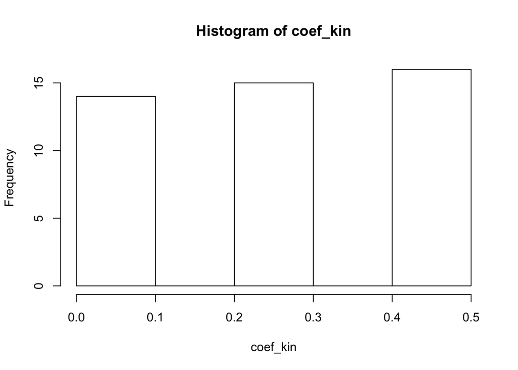

```r
hist(coef_kin)
```

**Ejercicio 9**

```r
knitr::kable(Inbred_fish, caption = "Genealogía con animales consanguíneos")
```

Genealogía con animales consanguíneos

| id | fatherid | motherid | sex | affected |
| --- | --- | --- | --- | --- |
| 1 | NA | NA | 1 | 1 |
| 2 | NA | NA | 2 | 0 |
| 3 | NA | NA | 1 | 0 |
| 4 | NA | NA | 2 | 0 |
| 5 | 1 | 2 | 1 | 0 |
| 6 | 1 | 2 | 1 | 0 |
| 7 | 3 | 4 | 2 | 0 |
| 8 | 6 | 7 | 1 | 0 |
| 9 | 6 | 7 | 1 | 0 |
| 10 | 6 | 7 | 2 | 1 |
| 11 | 9 | 10 | 1 | 1 |
| 12 | 9 | 10 | 2 | 1 |
| 13 | 11 | 12 | 1 | 1 |

**Ejercicio 10**

Cree un objeto pedigree denominado *Inbred_ped* con la nueva genealogía endogámica y grafiquela con la función plot().

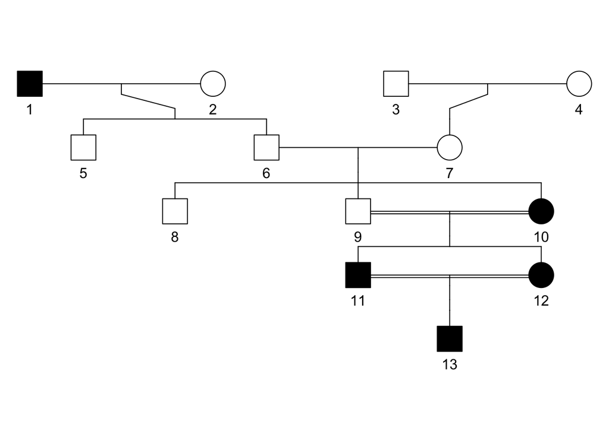

Genealogía de población consanguínea. Los individuos en negrita tienen albinismo

```r
Inbred_ped<-with(Inbred_fish,pedigree(id=id,dadid=fatherid,momid=motherid, sex=sex, affected = affected))

plot(Inbred_ped, cex = 1)
```

**Ejercicio 11**

En este ultimo ejercicio calculará el nivel de endogamia individual usando la función calcInbreeding() de la librería **pedigree**. Investigue como se usa esta función con el comando help(calcInbreeding) y luego calcule el nivel de consanguinidad individual.

Note que el comando **calcInbreeding()** requiere un objeto data.frame, pero nosotros hemos importado los datos con el comando **read_excel()** el cual crea un formato diferente llamado **tibble**. Un **tibble** es una estructura de datos muy similar a un data.frame pero tiene algunas diferencias que la hacen incompatible con el requerimiento de la función **calcInbreeding()**. Por lo tanto, antes de calcular el nivel de consanguinidad individual debe transformar el objeto Inbred_fish en un data.frame con el comando **as.data.frame(Inbred_fish)**. Finalmente visualice un resumen estadístico del nivel de inbreeding con la función summary().

```r
# Observe el formato tibble
class(Inbred_fish)
```

```
## [1] "tbl_df"     "tbl"        "data.frame"
```

```r
Inbred_fish <- as.data.frame(Inbred_fish)
# Observe el formato data.frame
class(Inbred_fish)
```

```
## [1] "data.frame"
```

```r
Inbred_ind <- calcInbreeding(Inbred_fish)

Inbred_ind
```

```
##  [1] 0.000 0.000 0.000 0.000 0.000 0.000 0.000 0.000 0.000 0.000 0.250 0.250
## [13] 0.375
```

```r
pander::pander(summary(Inbred_ind), caption = "Resumen de consanguinidad poblacional" )
```

Resumen de consanguinidad poblacional

| Min. | 1st Qu. | Median | Mean | 3rd Qu. | Max. |
| --- | --- | --- | --- | --- | --- |
| 0 | 0 | 0 | 0.06731 | 0 | 0.375 |

#### REFERENCIAS

**Gallardo, J.A., X. García, J. P. Lhorente and R. Neira.** 2004. Inbreeding and inbreeding depression of female reproductive traits in two populations of Coho salmon selected using BLUP predictors of breeding values. Aquaculture 234: 111-122. PDF

**Gallardo, J.A., J.P. Lhorente, X. García and R. Neira.** 2004. Effect of nonrandom mating schemes to delay the inbreeding accumulation in cultured populations of Coho salmon (*Oncorhynchus kisutch*). Can. J. Fish. Aqua. Sci. 61: 547-553. PDF

**Sinnwell J, P, Therneau T, M, Schaid D, J**. The kinship2 R Package for Pedigree Data. Hum Hered 2014;78:91-93. doi: 10.1159/000363105

**Sewall Wright**. Coefficients of Inbreeding and Relationship. The American Naturalist 1922 56:645, 330-338